# Coursework Report

*N* removed NAs: 3

*N* removed typo: 1

*N* removed <18: 26

*N* total clean: 120

| Group | *N* | *M*<sub>age</sub> | *M*<sub>rating</sub> |
| --- | --- | --- | --- |
| Control | 56 | 21.09 | 6.05 |
| Experim | 64 | 20.53 | 5.72 |

**Main analysis results**

*t*(118) = 2.55, *p* = .012

[interactive chart not shown]

[figure not shown]

[interactive chart not shown]

# Coursework Report

Analysing Data, Spring 2020

# Methods

## Participants

150 female participants were initially recruited to participate in this experiment. As a result of 4 participants neglecting to state their age, their data was omitted from the study. A further 26 participants were also removed from the study as a consequence of declaring to be under the age of 18. These participants were excluded from this dataset because of ethical reasons; ethical guidelines state that participants must be 18 or over. Therefore, the participants whose ages were not stated were removed as a precaution. Consequently, the final number of participants data included in this experiment was 120.

Table 1. displays the range, mean and standard deviation of the final number of participants ages who took part in the experiment.

Table 1. Descriptive statistics of Participants

| Mean age | SD of age | Minimum age | Maximum age |
| --- | --- | --- | --- |
| 20.79 | 2.06 | 18 | 26 |

Table 2. presented below provides descriptive statistics of the participants by experimental condition.

Table 2. Descriptive statistics by Condition

| Condition | N | Mean age | SD of age |
| --- | --- | --- | --- |
| control | 56 | 21.09 | 1.89 |
| experimental | 64 | 20.53 | 2.18 |

## Design

The purpose of this experiment was to investigate whether colour influences attractiveness. The independent variable in this study was the factor of colour. Participants were randomly allocated to either the control group or experimental group. Within the control group, participants viewed a black and white photo of a moderately attractive man on a white background. On the other hand, the experimental group saw the male on a red background. The colour white was selected in Elliot et al’s (2010) original study because white is considered a neutral colour. Furthermore, the perceived attractiveness rating of the male was the dependent variable. Participants were asked to rate the picture based on three items: “How attractive do you think this person is?”, “How pleasant is this person to look at?” and “If I were to meet the person in this picture face to face, I would think he is attractive.” Female participants perceived attractiveness ratings were assessed using a scale from 1 (not attractive) to 9 (very attractive). The three ratings from each participant were added together and divided by the number of items to obtain a composite mean score of attractiveness ratings. In conclusion, this experiment examined if female’s perceived attractiveness ratings of a moderately attractive man would differ depending on whether the male was depicted on a red or white background. In order to decipher if the results from the experiment were statistically significant, the independent *t*-test was conducted to analyse participants composite scores.

# Results

This report investigated the extent to which the colours red (experimental group) and white (control group) impacted female participants mean attractiveness ratings of a moderately attractive male. Results from this experiment depict the control group as having a slightly higher mean attractiveness ratings across all three items than the experimental group (see Table 3.).

Table 3. Descriptive statistics of Item ratings per condition

| Condition | Item 1 Mean | Item 1 SD | Item 2 Mean | Item 2 SD | Item 3 Mean | Item 3 SD |
| --- | --- | --- | --- | --- | --- | --- |
| control | 5.95 | 1.35 | 5.98 | 1.38 | 6.23 | 1.41 |
| experimental | 5.84 | 1.41 | 5.73 | 1.38 | 5.58 | 1.39 |

The graph below illustrates the Mean Attractiveness Ratings for each experimental condition.

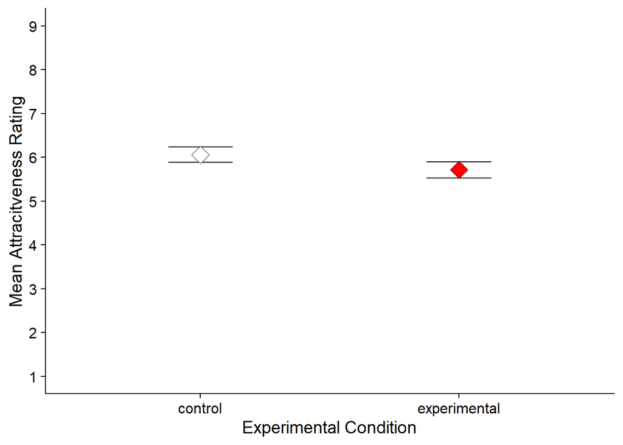

An independent-measures *t*-test was performed to analyse if the composite attractiveness scores in each condition were statistically significant. The *t*-test indicated that the control condition had a slightly higher mean rating of attractiveness (*M* = 6.05) than the experimental condition (*M* = 5.72). Consequently, this difference in means was not statistically significant when compared to *p* < .001 (*M*<sub>diff</sub> = 0.33, 95% CI [0.08, 0.59], *t* (118) = 2.55, *p* = .012). In conclusion, colour did not affect women’s attractiveness ratings, consequently the null hypothesis is accepted and the alternative hypothesis that colour influences percieved attractiveness is rejected.

# Discussion

This research aimed to investigate whether the colour red influenced women’s perceived attractiveness of a moderately attractive male. Results from the experiment revealed the control group (who viewed the male on a white background) to have a slightly higher mean attractiveness rating than the experimental group (who viewed the male on a red background). Subsequent statistical analysis indicated that these results were not significant, suggesting that colour does not influence attractiveness. Findings gathered from the present study were in opposition to Elliot et al’s (2010) original Experiment 1. Conversely, Elliot et al’s (2010) research discovered the colour red to be statistically significant in influencing female’s attractiveness ratings of the composite male. Therefore, definitive conclusions that colour does influence attractiveness cannot be made as a result of these inconsistent results.

Other research and replications of Elliot et al’s (2010) experiments have also produced conflicting results from the original study. Hesslinger, Goldbach and Carbon’s (2015) replication discovered a similar pattern of results to the present study. Their results revealed the experimental group to have a slightly higher mean attractiveness rating than the control group, however, this difference was not statistically significant. Thus, colour did not influence female’s attractiveness ratings. In addition, Francis (2013) questioned the credibility of Elliot et al’s (2010) research as a result of finding evidence of publication bias. Francis (2013) argues that experiments resulting in null outcomes were omitted from publication and the experiments that were published were conducted in favour of his hypothesis. In order to address these claims, Elliot and Maier (2013) replicated Elliot et al’s (2010) original experiment. The experimental group depicted a slightly higher mean attractiveness rating than the control group, nevertheless, these results were not statistically significant. To conclude this section, the literature identifies research which opposes Elliot et al’s (2010) original findings; consequently, concrete conclusions that colour influences attractiveness cannot be made.

A limitation of this experiment was that data was gathered from a small sample; it is unclear whether removing 30 participants because of ethical reasons would have subsequently impacted the significance of the results. Additionally, the experimental sample was composed of Undergraduate students. Thus, limiting the generalisability of the results to the wider population. Consequently, future research into this topic may want to gather data from a larger sample, as demonstrated in Elliot and Niesta’s (2013) study, in order to make the sample representative of the population. Furthermore, conducting experiments in multiple countries and including a variety of age groups is likely to increase the generalizability of results (Elliot et al, 2010). Future research may also want to investigate further the relationship that Roberts and Owen (2010) discovered between the psychological influence that wearing red can have on men’s expressions and posture which increases their attractiveness. Thus, further examination is required to discover how a colour can influence an individual’s subtle behaviours and in turn increase their perceived attractiveness.

In conclusion, this experiment discovered that the colour red did not influence female’s perceived attractiveness ratings of a moderately attractive man. The present study and other replications (Hesslinger, Goldbach and Carbon, 2015) do not support Elliot et al’s (2010) original research which suggested that colour does influence attractiveness.

# References

Elliot, A., Niesta Kayser, D., Greitemeyer, T., Lichtenfeld, S., Gramzow, R., Maier, M., & Liu, H. (2010). Red, rank, and romance in women viewing men. *Journal of Experimental Psychology: General, 139*(3), 399-417.

Elliot, A.J. & Maier, M.A. (2013). The Red-Attractiveness Effect, Applying the Ioannidis and Trikalinos (2007b) Test, and the Broader Scientific Context: A Reply to Francis (2013). *Journal of Experimental Psychology, 142*(1), 297-300.

Francis, G. (2013). Publication Bias in “Red, Rank, and Romance in Women Viewing Men,” by Elliot et al. (2010). *Journal of Experimental Psychology, 142*(1), 292-296.

Hesslinger, V., Goldbach, L., & Carbon, C. (2015). Men in red: A reexamination of the red-attractiveness effect. *Psychonomic Bulletin & Review, 22*(4), 1142-1148.

Roberts, C.S & Owen, R.C. (2010). Distinguishing between perceiver and wearer effects in clothing colour associated attributions. *Evolutionary Psychology, 8*(3), 350-364.

Thorstenson, C. A., Pazda, A. D., Elliot, A. J., and Perrett, D. I. (2017). Facial redness increases men’s perceived healthiness and attractiveness. *Perception, 46*(6), 650–664.